# Figure 1

# 1 Loading libraries

```r
pacman::p_load(tidyverse,
               broom,
               ggbeeswarm,
               survminer,
               survival)
```

# 2 Figure 1A Inter-species (survival)

## 2.1 Import data

Import mortality data in long format in 3 species of *Acropora*.

```r
survival_data_long_list <-
  list.files(recursive = F,
             pattern = 'daily-survival-data.csv',
             full.names = F)

survival_data_long <-
  read_csv(survival_data_long_list,
           id = 'file_name') |>
  select(!1)
```

Export.

```r
write_csv(survival_data_long,
          file = 'Figure-01-A-tables/daily-survival-data.csv')
```

## 2.2 Clean data

Among the *Acropora* species, only *A. tenuis* showed mortality in the control tanks during exposure. These will not be included in further analyses, cutting the *A. tenuis* colonies that will be included to 25.

These colonies are: ATEN07, ATEN08, ATEN09, ATEN24, ATEN25.

```r
unresolved_colonies <- c("ATEN07","ATEN08","ATEN09","ATEN24","ATEN25")

survival_data_long <-
  survival_data_long |>
  filter(!Colony %in% unresolved_colonies)
```

Filter data to only include thermally challenged setups. Note that control tanks were only set to check that stress is not confounded by handling stress.

```r
survival_data_long_hstressed <-
  survival_data_long |>
  filter(Treatment == 'Heat-stressed')
```

## 2.3 Do statistics

Before doing any plot-related work, set a color palette.

```r
species_color_palette <- c("#294557","#558981","#C6BF88")
```

Comparison of measures of central tendency was done at first but it was deemed that comparison of survival curves is more appropriate.

### 2.3.1 Kaplan-Meier curves

Shape data to be appropriate for survival curves analysis.

```r
survival_data_long_hstressed_surv <-
  survival_data_long_hstressed |>
  select(c(1,4,5,7:9))

# Make a tibble for A. millepora that extends to 13 days (for comparison with Adig)
survival_data_long_hstressed_surv_amil <-
  survival_data_long_hstressed_surv |>
  filter(Species == 'A. millepora') |>
  distinct(Colony,
           .keep_all = T) |>
  mutate('Days elapsed 11' = 11,
         'Days elapsed 12' = 12,
         'Days elapsed 13' = 13,
         `Healthy fragments` = NA) |>
  select(!`Day elapsed`) |>
  pivot_longer(cols = !c(1:5),names_to = 'Days',values_to = 'Day elapsed') |>
  select(!Days)

# Make a tibble for A. millepora that extends to 13 days (for comparison with Adig)
survival_data_long_hstressed_surv_aten <-
  survival_data_long_hstressed_surv |>
  filter(Species == 'A. tenuis') |>
  distinct(Colony,
           .keep_all = T) |>
  mutate('Days elapsed 11' = 11,
         'Days elapsed 12' = 12,
         'Days elapsed 13' = 13,
         `Healthy fragments` = NA) |>
  select(!`Day elapsed`) |>
  pivot_longer(cols = !c(1:5),names_to = 'Days',values_to = 'Day elapsed') |>
  select(!Days)

# Combine all tibbles
survival_data_long_hstressed_surv <-
  survival_data_long_hstressed_surv |>
  bind_rows(survival_data_long_hstressed_surv_amil,
            survival_data_long_hstressed_surv_aten)|>
  mutate(`Healthy fragments` = case_when(`Healthy fragments` == NA ~ 1,
                                         .default = `Healthy fragments`))
```

Make a dataframe that with status (censor).

```r
survival_data_long_hstressed_surv_frags <-
  survival_data_long_hstressed_surv |>
  # Make a string, delimited by comma to make ID fragments
  rowwise() %>%
  mutate('Fragment ID' = paste0(Colony,
                                '_',
                                seq_len(`N fragment`),
                                collapse = ",")) %>%
  ungroup() %>%
  # Separate them
  separate(`Fragment ID`,
           into = paste0("Fragment ID_",
                         1:max(str_count(.$`Fragment ID`, ",")) + 1),
           sep = ",",
           remove = F,
           extra = 'merge') |>
  separate(`Fragment ID_8`,
           into = c('Fragment ID_9', 'Fragment ID_10'),
           sep = ",",
           remove = T) |>
  # Remove Fragment ID
  select(!`Fragment ID`) |>
  # Make tibble longer
  pivot_longer(cols = 7:14,
               values_to = 'Fragment ID',
               values_drop_na = T) |>
  select(!name) |>
  mutate('Fragment #' = str_sub(`Fragment ID`, -1, -1),
         'Fragment #' = as.numeric(`Fragment #`)) |>
  mutate(status = case_when(`Healthy fragments` == NA ~ 1,
                            `Healthy fragments` < `Fragment #` ~ 2,
                            .default = 1))
```

Export shaped tibble.

```r
write_csv(survival_data_long_hstressed_surv_frags,
          file = 'Figure-01-A-tables/daily-survival-data_survminer.csv')
```

Make plot.

```r
# Fit data
survival_data_long_hstressed_surv_frags_fit <-
  survfit(Surv(`Day elapsed`, status) ~ Species, data = survival_data_long_hstressed_surv_frags)

# Plot data
survival_data_long_hstressed_surv_frags_fit_plot <-
  ggsurvplot(survival_data_long_hstressed_surv_frags_fit,
             conf.int = T,
             data = survival_data_long_hstressed_surv_frags,
             palette = species_color_palette,
             censor.shape = NA, ylim = c(.80, 1),
             size = 1.5,
             legend = 'right')
```

Export plot.

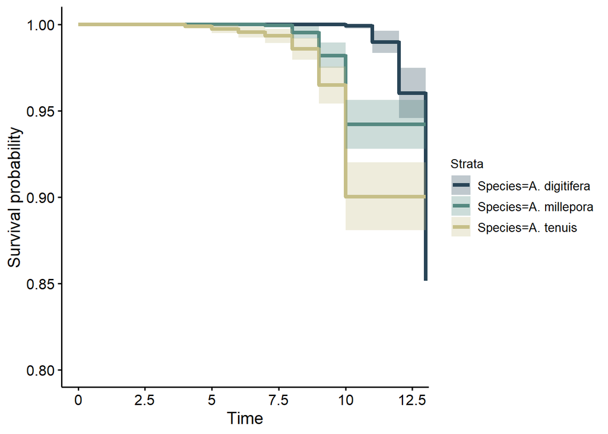

```r
survival_data_long_hstressed_surv_frags_fit_plot
```

```r
ggsave('Figure-01-A.png',
       dpi = 900,
       width = 7000,
       height = 3000,
       units = "px")
```

Make pairwise test.

```r
survival_data_long_hstressed_surv_frags_pval <-
  surv_pvalue(survival_data_long_hstressed_surv_frags_fit,
                    data = survival_data_long_hstressed_surv_frags)

survival_data_long_hstressed_surv_frags_pwise <-
  pairwise_survdiff(Surv(`Day elapsed`, status) ~ Species,
                    data = survival_data_long_hstressed_surv_frags) |>
  tidy()
```

Export stat tables.

```r
write_csv(survival_data_long_hstressed_surv_frags_pval,
          'Figure-01-A-tables/km_log-rank_global.csv')

write_csv(survival_data_long_hstressed_surv_frags_pwise,
          'Figure-01-A-tables/km_log-rank_pairwise.csv')
```

# 3 Figure 1B Intra-species (survival, MIG)

## 3.1 Survival

### 3.1.1 Clean data

Shape the initially imported data. For this analysis, only the last day per species will be considered to get the proportion of fragment bleached at end of exposure (% survival).

```r
survival_data_long_hstressed_b <-
  survival_data_long_hstressed |>
  filter(`Day elapsed` >= 10) |>
  filter(!(Species == 'A. digitifera' & `Day elapsed` >= 10 & `Day elapsed` < 13)) |>
  mutate('% bleaching' = `Healthy fragments`/`N fragment` * 100) |>
  group_by(Species) |>
  mutate(Colony = case_when(Species == 'A. digitifera' ~ paste0('D', str_sub(Colony,5,6)),
                            Species =='A. tenuis' ~ paste0('T', str_sub(Colony,5,6)),
                            Species == 'A. millepora' ~ paste0('M', str_sub(Colony,5,6)),
                            .default = Colony))
```

### 3.1.2 Plot

```r
survival_data_long_hstressed_b_p <-
  survival_data_long_hstressed_b |>
  ggplot(aes(y = reorder(Colony, `% bleaching`),
             x = `% bleaching`,
             fill = Species)) +
  geom_bar(stat = 'identity') +
  labs(y = 'Colony ID') +
  facet_grid(rows = vars(Species),
             scales = 'free',
             space = 'free') +
  scale_fill_manual(values = species_color_palette) +
  theme_bw() +
  theme(panel.grid = element_blank(),
        strip.text = element_blank())
```

Export plot.

```r
ggsave(plot = survival_data_long_hstressed_b_p,
       filename = 'Figure-01-B.png',
       dpi = 900,
       width = 2500,
       height = 10000,
       units = "px")
```

## 3.2 Mean intensity gray

### 3.2.1 A. digitifera

Import pre-exposure MIG data.

```r
mig_adig_pre <-
  read_csv('Figure-01-adig-all-pre_mig-data.csv') |>
  mutate(Replicate = rep(c(1,2),
                         length.out = n()))
```

Import post-exposure MIG data.

```r
mig_adig_post <-
  read_csv('Figure-01-adig-all-post_mig-data.csv') |>
  mutate(Replicate = rep(c(1,2),
                         length.out = n()))
```

Merge.

```r
mig_adig <-
  mig_adig_pre |>
  left_join(mig_adig_post,
            by = c('Colony ID',
                   'Tank ID',
                   'Treatment',
                   'Replicate'),
            suffix = c(".pre", ".post"))
```

Compute change.

```r
mig_adig_change <-
  mig_adig |>
  mutate('% change' = (`Normalized mean gray value.post` - `Normalized mean gray value.pre`)/`Normalized mean gray value.pre` * 100)


mig_adig_change_ave <-
  mig_adig_change |>
  drop_na() |>
  group_by(`Colony ID`, Treatment) |>
  summarise('mean' = mean(`% change`))
mig_adig_change_median <-
  mig_adig_change |>
  drop_na() |>
  group_by(`Colony ID`, Treatment) |>
  summarise('median' = median(`% change`))
```

### 3.2.2 A. millepora

Import pre-exposure MIG data.

```r
mig_amil_pre <-
  read_csv('Figure-01-amil-all-pre_mig-data.csv') |>
  mutate(Replicate = rep(c(1,2),
                         length.out = n()))
```

Import post-exposure MIG data.

```r
mig_amil_post <-
  read_csv('Figure-01-amil-all-post_mig-data.csv') |>
  mutate(Replicate = rep(c(1,2),
                         length.out = n()))
```

Merge.

```r
mig_amil <-
  mig_amil_pre |>
  left_join(mig_amil_post,
            by = c('Colony ID',
                   'Tank ID',
                   'Treatment',
                   'Replicate'),
            suffix = c(".pre", ".post"))
```

Compute change.

```r
mig_amil_change <-
  mig_amil |>
  mutate('% change' = (`Normalized mean gray value.post` - `Normalized mean gray value.pre`)/`Normalized mean gray value.pre` * 100)


mig_amil_change_ave <-
  mig_amil_change |>
  drop_na() |>
  group_by(`Colony ID`, Treatment) |>
  summarise('mean' = mean(`% change`))
mig_amil_change_median <-
  mig_amil_change |>
  drop_na() |>
  group_by(`Colony ID`, Treatment) |>
  summarise('median' = median(`% change`))
```

### 3.2.3 A. tenuis

Import pre-exposure MIG data.

```r
mig_aten_pre <-
  read_csv('Figure-01-aten-all-pre_mig-data.csv')
```

Import post-exposure MIG data.

```r
mig_aten_post <-
  read_csv('Figure-01-aten-all-post_mig-data.csv')
```

Import pre-exposure MIG data.

```r
mig_data_pre_list <-
  list.files(recursive = F,
             pattern = '*all-pre_mig-data.csv',
             full.names = F)

mig_data_pre_long <-
  read_csv(mig_data_pre_list,
           id = 'file_name') |>
  select(!1) |>
  select(!c(3,4))
```

Import post-exposure MIG data.

```r
mig_data_post_list <-
  list.files(recursive = F,
             pattern = '*all-post_mig-data.csv',
             full.names = F)

mig_data_post_long <-
  read_csv(mig_data_post_list,
           id = 'file_name') |>
  select(!1) |>
  select(!c(3,4))
```

Merge tibbles.

```r
mig_data <-
  mig_data_pre_long |>
  left_join(mig_data_post_long,
            by = 'Colony ID')
```